# Kaggle Airbnb Analysis

biktik R’tik

27 08 2020

# Package Installation

```r
library(tidyverse)
library(dplyr)
library(ggplot2)
library(lubridate)
library(tidyr)
library(rio)
```

# Reading Data

```r
raw_df <- read.csv("C:/Users/Suhey/OneDrive/Masaüstü/IE48A/Airbnb.csv")
```

Observing data and it’s structure.

```r
raw_df %>% glimpse()
```

```
## Rows: 48,895
## Columns: 16
## $ id                             <int> 2539, 2595, 3647, 3831, 5022, 5099, ...
## $ name                           <chr> "Clean & quiet apt home by the park"...
## $ host_id                        <int> 2787, 2845, 4632, 4869, 7192, 7322, ...
## $ host_name                      <chr> "John", "Jennifer", "Elisabeth", "Li...
## $ neighbourhood_group            <chr> "Brooklyn", "Manhattan", "Manhattan"...
## $ neighbourhood                  <chr> "Kensington", "Midtown", "Harlem", "...
## $ latitude                       <dbl> 40.64749, 40.75362, 40.80902, 40.685...
## $ longitude                      <dbl> -73.97237, -73.98377, -73.94190, -73...
## $ room_type                      <chr> "Private room", "Entire home/apt", "...
## $ price                          <int> 149, 225, 150, 89, 80, 200, 60, 79, ...
## $ minimum_nights                 <int> 1, 1, 3, 1, 10, 3, 45, 2, 2, 1, 5, 2...
## $ number_of_reviews              <int> 9, 45, 0, 270, 9, 74, 49, 430, 118, ...
## $ last_review                    <chr> "2018-10-19", "2019-05-21", "", "201...
## $ reviews_per_month              <dbl> 0.21, 0.38, NA, 4.64, 0.10, 0.59, 0....
## $ calculated_host_listings_count <int> 6, 2, 1, 1, 1, 1, 1, 1, 1, 4, 1, 1, ...
## $ availability_365               <int> 365, 355, 365, 194, 0, 129, 0, 220, ...
```

```r
head(raw_df)
```

```
##     id                                             name host_id   host_name
## 1 2539               Clean & quiet apt home by the park    2787        John
## 2 2595                            Skylit Midtown Castle    2845    Jennifer
## 3 3647              THE VILLAGE OF HARLEM....NEW YORK !    4632   Elisabeth
## 4 3831                  Cozy Entire Floor of Brownstone    4869 LisaRoxanne
## 5 5022 Entire Apt: Spacious Studio/Loft by central park    7192       Laura
## 6 5099        Large Cozy 1 BR Apartment In Midtown East    7322       Chris
##   neighbourhood_group neighbourhood latitude longitude       room_type price
## 1            Brooklyn    Kensington 40.64749 -73.97237    Private room   149
## 2           Manhattan       Midtown 40.75362 -73.98377 Entire home/apt   225
## 3           Manhattan        Harlem 40.80902 -73.94190    Private room   150
## 4            Brooklyn  Clinton Hill 40.68514 -73.95976 Entire home/apt    89
## 5           Manhattan   East Harlem 40.79851 -73.94399 Entire home/apt    80
## 6           Manhattan   Murray Hill 40.74767 -73.97500 Entire home/apt   200
##   minimum_nights number_of_reviews last_review reviews_per_month
## 1              1                 9  2018-10-19              0.21
## 2              1                45  2019-05-21              0.38
## 3              3                 0                            NA
## 4              1               270  2019-07-05              4.64
## 5             10                 9  2018-11-19              0.10
## 6              3                74  2019-06-22              0.59
##   calculated_host_listings_count availability_365
## 1                              6              365
## 2                              2              355
## 3                              1              365
## 4                              1              194
## 5                              1                0
## 6                              1              129
```

Converting data format form csv to rds in order to manipulate data easily

```r
export(raw_df, "Airbnb.csv")
saveRDS(raw_df, file = "Airbnb.csv")
convert("Airbnb.csv", "Airbnb.rds")
```

### Effect of Neighbourhood Groups on Prices

Creating a new data frame in order to see the effect of neighbourhood on prices

```r
data1<-raw_df %>% group_by(neighbourhood_group)%>%summarise(AvgPrice=mean(price))
```

**Visualization of the relation between price and neighbourhood groups.**

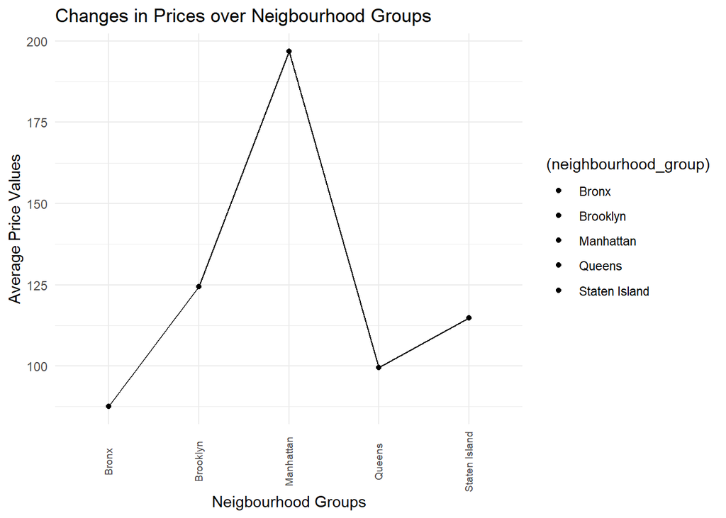

```r
ggplot(data1,aes(x=neighbourhood_group,y=AvgPrice,group=1,fill=(neighbourhood_group)))+
 ggtitle("Changes in Prices over Neigbourhood Groups")+ geom_point()+
 geom_line()+
 theme_minimal() +
 labs(x = "Neigbourhood Groups",y = "Average Price Values") +
 theme(axis.text.x = element_text(angle =90,size=7,vjust=0.4))
```

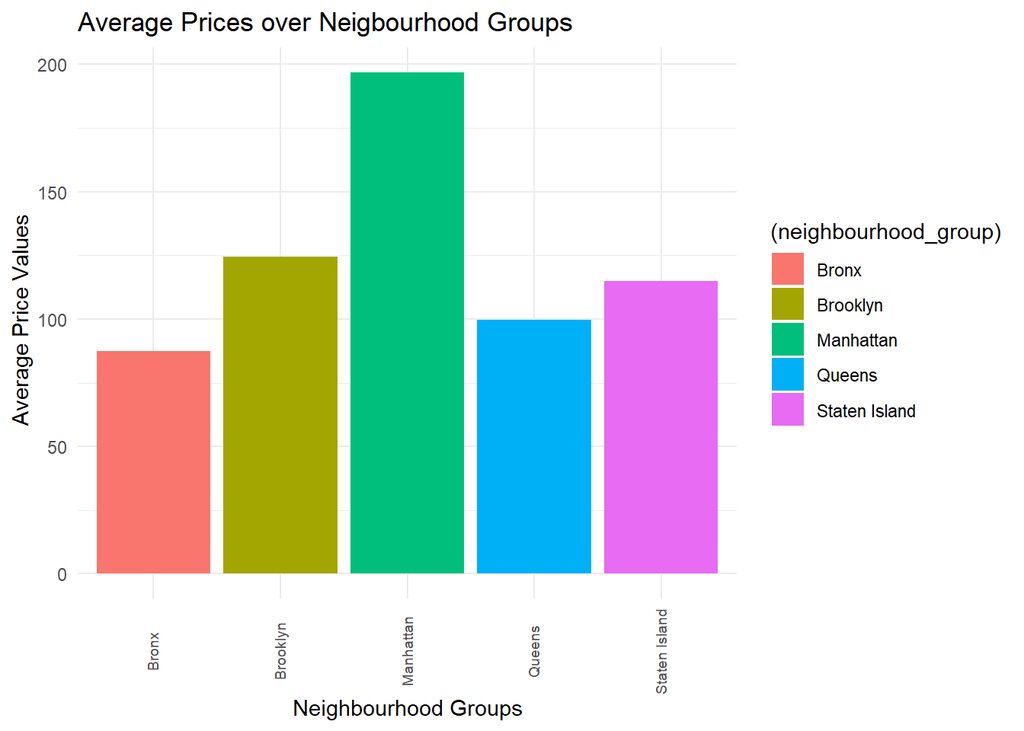

```r
ggplot(data1,aes(x=neighbourhood_group,y=AvgPrice,fill=(neighbourhood_group))) +
  geom_bar(stat="identity",position="dodge") +
  theme_minimal() +
  labs(x="Neighbourhood Groups",y=" Average Price Values",title="Average Prices over Neigbourhood Groups") +
  theme(axis.text.x = element_text(angle=90,size=7,vjust=0.4))
```

This plot makes it easier to see the outliers in room prices according to different neighbourhood groups.

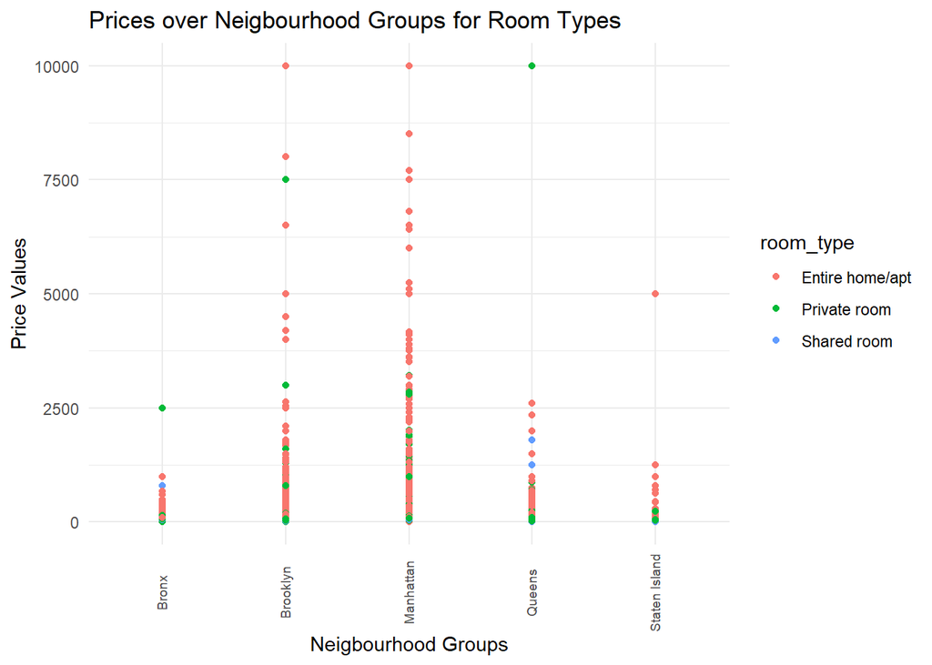

```r
ggplot(raw_df,aes(x=neighbourhood_group,y=price,group=1,color=room_type))+
  ggtitle(label="Prices over Neigbourhood Groups for Room Types")+
  theme(plot.title = element_text(hjust=1))+
  geom_point()+
  theme_minimal() +
  labs(x = "Neigbourhood Groups",y = "Price Values") +
  theme(axis.text.x = element_text(angle =90,size=7,vjust=0.4))
```

# Conclusion 1:

Average price of rooms changes according to neighbourhood groups. Room prices are more expensive in Manhattan and Brooklyn than other neighbourhood groups.

### Relation between Neighbourhood Groups and Availability of Room

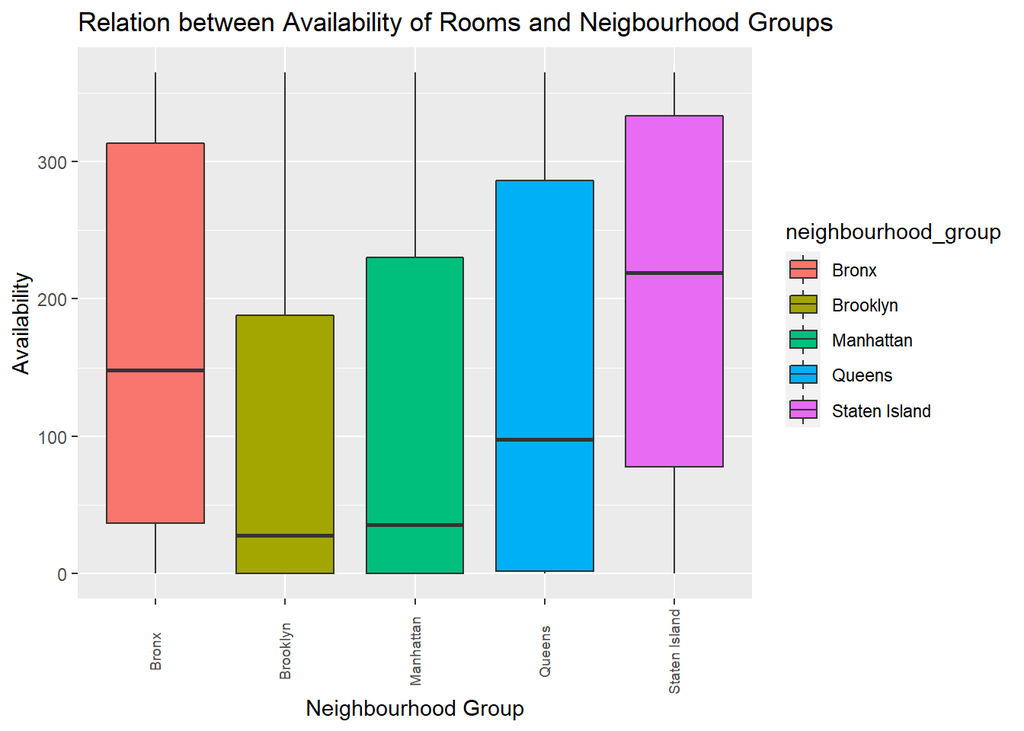

```r
ggplot(raw_df, aes(x=neighbourhood_group, y=availability_365, fill=neighbourhood_group)) +
  labs(x="Neighbourhood Group",y="Availability",title="Relation between Availability of Rooms and Neigbourhood Groups")+
  geom_boxplot()+
  theme(axis.text.x = element_text(angle=90,size=7,vjust=0.4))
```

### Relation between Number of Rooms and Different Neighbourhood Groups

```r
piedata<-aggregate(cbind(count = neighbourhood_group) ~ neighbourhood_group,
                   data = raw_df,
                   FUN = function(x){NROW(x)})
```

**Visualization of number of rooms in different neighbourhood groups.**

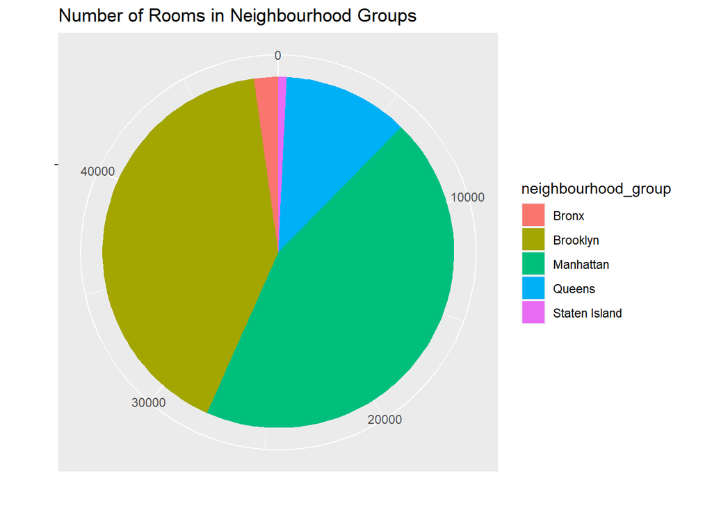

```r
ggplot(piedata,aes(x="",y=count,fill=neighbourhood_group)) +
  labs(x="",y="",title="Number of Rooms in Neighbourhood Groups")+
  geom_bar(stat="identity",width=1) + coord_polar("y")
```